# AED DPLYR - Aula 2

Fabrício Venturim

2023-05-17

```r
if(!require(utf8)) install.packages("utf8")
library(utf8)
Sys.setlocale("LC_ALL", "pt_br.utf-8")
```

```
## [1] "LC_COLLATE=pt_br.utf-8;LC_CTYPE=pt_br.utf-8;LC_MONETARY=pt_br.utf-8;LC_NUMERIC=C;LC_TIME=pt_br.utf-8"
```

```r
if(!require(tidyverse)) install.packages("tidyverse")
library("tidyverse")
```

# 1 Motivação

Neste material, abordaremos três elementos fundamentais para a criação e visualização de gráficos no R e que serão de extrema importancia para as tarefas e para a A2: o operador de pipe (%>%), as principais funções do pacote dplyr e o conceito de facetamento.

Gráficos são poderosas ferramentas para comunicar informações e insights a partir dos dados. A capacidade de criar visualizações eficazes é essencial em muitos campos.

Ao dominar o operador de pipe, as principais funções do dplyr e o conceito de facetamento, você estará equipado para criar gráficos sofisticados e informativos para seus trabalhos, relatórios e apresentações. Essas ferramentas fornecem uma base sólida para explorar e comunicar insights a partir dos dados, ajudando a tornar suas visualizações mais poderosas e eficazes.

Vamos agora explorar cada um desses elementos em detalhes, fornecendo exemplos práticos e dicas para aprimorar suas habilidades de visualização no R.

# 2 Operador pipe `%>%`

O operador `%>%` (pipe) foi uma das grandes revoluções recentes do R, tornando a escrita e leitura de códigos mais intuitiva e compreensível.

É importante compreender seu funcionamento, pelo menos, para conseguir ler códigos da internet e entender como funcionam

[figure not shown]

A ideia do operador `%>%` (pipe) é bem simples: usar o valor resultante da expressão do lado esquerdo como primeiro argumento da função do lado direito.

```r
f = function(x, y){
  return(x+y)
}
```

```r
x = 1
y = 2
```

```r
f(x, y)
```

```
## [1] 3
```

```r
x %>% f(y)
```

```
## [1] 3
```

Nos casos mais simples, o pipe parece não trazer grandes vantagens. Agora, veja como fica um caso com mais etapas.

Vamos calcular a raiz quadrada da soma dos valores de 1 a 4. Primeiro, sem o pipe.

```r
x <- c(1, 2, 3, 4)
sqrt(sum(x))
```

```
## [1] 3.162278
```

```r
x %>% sum() %>% sqrt()
```

```
## [1] 3.162278
```

O caminho que o código `x %>% sum %>% sqrt` seguiu foi enviar o objeto `x` como argumento da função `sum()` e, em seguida, enviar a saida da expressão `sum(x)` como argumento da função `sqrt()`. Observe que escrevemos o código na mesma ordem em que as operações são realizadas. A utilização de parênteses após o nome das funções não é necessário, mas recomendável.

## 2.1 Receita de Bolo

Ingredientes:

- 2 xícaras de farinha
- 1/2 xícara de água
- 1 colher de chá de fermento
- 1/2 xícara de leite
- 2 colheres de sopa de óleo

Instruções:

1. Em um recipiente, misture as 2 xícaras de farinha, a água, o fermento, o leite e o óleo. Bata bem até obter uma massa macia.
2. Adicione mais farinha à massa até que fique macia e fácil de manusear. Continue batendo até obter a consistência desejada.
3. Despeje a massa em uma forma grande previamente untada.
4. Asse no forno por aproximadamente 50 minutos, ou até que o bolo fique dourado e firme ao toque.
5. Retire o bolo do forno e deixe esfriar em temperatura ambiente por cerca de 20 minutos.
6. Transfira o bolo para a geladeira e deixe esfriar por mais 20 minutos antes de servir.

```
esfrie(
  asse(
    coloque(
      bata(
        acrescente(
          recipiente(
            rep("farinha", 2),
            "água",
            "fermento",
            "leite",
            "óleo"
          ),
          "farinha",
          ate = "macio"
        ),
        duracao = "3min"
      ),
      lugar = "forma",
      tipo = "grande",
      untada = TRUE
    ),
    duracao = "50min"
  ),
  lugar = "geladeira",
  duracao = "20min"
)
```

```
recipiente(rep("farinha", 2), "água", "fermento", "leite", "óleo") %>%
  acrescente("farinha", ate = "macio") %>%
  bata(duracao = "3min") %>%
  coloque(lugar = "forma", tipo = "grande", untada = TRUE) %>%
  asse(duracao = "50min") %>%
  esfrie(lugar = "geladeira", duracao = "20min")
```

Iremos utilizar mais ele ao estudar as funções do `Dplyr`.

# 3 DPLYR

- **select():** seleciona colunas de dados
- **arrange():** classifica os dados
- **mutate():** cria novas variáveis
- **filter():** subconjuntos de linhas de dados
- **group_by():** dados agregados
- **summarise():** resume dados (cálculo de estatísticas resumidas)

## 3.1 `select()`

No R, a função `select()` faz parte do pacote dplyr e é usada para selecionar colunas específicas de um data frame. Ela permite criar um novo data frame contendo apenas as colunas desejadas ou descartar colunas indesejadas de um data frame existente.

Selecionando apenas as colunas “mpg”, “cyl” e “gear” do dataframe mtcars

```r
data <- mtcars
```

```r
mtcars_selecionado <- select(mtcars, mpg, cyl, gear)
head(mtcars_selecionado)
```

```
##                    mpg cyl gear
## Mazda RX4         21.0   6    4
## Mazda RX4 Wag     21.0   6    4
## Datsun 710        22.8   4    4
## Hornet 4 Drive    21.4   6    3
## Hornet Sportabout 18.7   8    3
## Valiant           18.1   6    3
```

```r
mtcars_selecionado <- select(mtcars, mpg:hp)
head(mtcars_selecionado)
```

```
##                    mpg cyl disp  hp
## Mazda RX4         21.0   6  160 110
## Mazda RX4 Wag     21.0   6  160 110
## Datsun 710        22.8   4  108  93
## Hornet 4 Drive    21.4   6  258 110
## Hornet Sportabout 18.7   8  360 175
## Valiant           18.1   6  225 105
```

## 3.2 `arrange()`

A [`arrange()`](https://dplyr.tidyverse.org/reference/arrange.html) permite ordenar as linhas de um data frame com base nos valores de uma ou mais colunas.

```r
data <- mtcars
head(data)
```

```
##                    mpg cyl disp  hp drat    wt  qsec vs am gear carb
## Mazda RX4         21.0   6  160 110 3.90 2.620 16.46  0  1    4    4
## Mazda RX4 Wag     21.0   6  160 110 3.90 2.875 17.02  0  1    4    4
## Datsun 710        22.8   4  108  93 3.85 2.320 18.61  1  1    4    1
## Hornet 4 Drive    21.4   6  258 110 3.08 3.215 19.44  1  0    3    1
## Hornet Sportabout 18.7   8  360 175 3.15 3.440 17.02  0  0    3    2
## Valiant           18.1   6  225 105 2.76 3.460 20.22  1  0    3    1
```

```r
data <- mtcars %>% arrange(desc(mpg))
head(data)
```

```
##                 mpg cyl  disp  hp drat    wt  qsec vs am gear carb
## Toyota Corolla 33.9   4  71.1  65 4.22 1.835 19.90  1  1    4    1
## Fiat 128       32.4   4  78.7  66 4.08 2.200 19.47  1  1    4    1
## Honda Civic    30.4   4  75.7  52 4.93 1.615 18.52  1  1    4    2
## Lotus Europa   30.4   4  95.1 113 3.77 1.513 16.90  1  1    5    2
## Fiat X1-9      27.3   4  79.0  66 4.08 1.935 18.90  1  1    4    1
## Porsche 914-2  26.0   4 120.3  91 4.43 2.140 16.70  0  1    5    2
```

```r
data <- mtcars %>% arrange(cyl, desc(disp))
head(data)
```

```
##                mpg cyl  disp  hp drat    wt  qsec vs am gear carb
## Merc 240D     24.4   4 146.7  62 3.69 3.190 20.00  1  0    4    2
## Merc 230      22.8   4 140.8  95 3.92 3.150 22.90  1  0    4    2
## Volvo 142E    21.4   4 121.0 109 4.11 2.780 18.60  1  1    4    2
## Porsche 914-2 26.0   4 120.3  91 4.43 2.140 16.70  0  1    5    2
## Toyota Corona 21.5   4 120.1  97 3.70 2.465 20.01  1  0    3    1
## Datsun 710    22.8   4 108.0  93 3.85 2.320 18.61  1  1    4    1
```

## 3.3 `mutate()`

O que faz: adiciona novas colunas ou modifica as variáveis atuais no conjunto de dados.

```r
diamonds
```

```
## # A tibble: 53,940 × 10
##    carat cut       color clarity depth table price     x     y     z
##    <dbl> <ord>     <ord> <ord>   <dbl> <dbl> <int> <dbl> <dbl> <dbl>
##  1  0.23 Ideal     E     SI2      61.5    55   326  3.95  3.98  2.43
##  2  0.21 Premium   E     SI1      59.8    61   326  3.89  3.84  2.31
##  3  0.23 Good      E     VS1      56.9    65   327  4.05  4.07  2.31
##  4  0.29 Premium   I     VS2      62.4    58   334  4.2   4.23  2.63
##  5  0.31 Good      J     SI2      63.3    58   335  4.34  4.35  2.75
##  6  0.24 Very Good J     VVS2     62.8    57   336  3.94  3.96  2.48
##  7  0.24 Very Good I     VVS1     62.3    57   336  3.95  3.98  2.47
##  8  0.26 Very Good H     SI1      61.9    55   337  4.07  4.11  2.53
##  9  0.22 Fair      E     VS2      65.1    61   337  3.87  3.78  2.49
## 10  0.23 Very Good H     VS1      59.4    61   338  4     4.05  2.39
## # ℹ 53,930 more rows
```

```r
data <- diamonds %>%
  mutate(JustOne = 1,
         Values = "something",
         Simple = TRUE)

data
```

```
## # A tibble: 53,940 × 13
##    carat cut    color clarity depth table price     x     y     z JustOne Values
##    <dbl> <ord>  <ord> <ord>   <dbl> <dbl> <int> <dbl> <dbl> <dbl>   <dbl> <chr>
##  1  0.23 Ideal  E     SI2      61.5    55   326  3.95  3.98  2.43       1 somet…
##  2  0.21 Premi… E     SI1      59.8    61   326  3.89  3.84  2.31       1 somet…
##  3  0.23 Good   E     VS1      56.9    65   327  4.05  4.07  2.31       1 somet…
##  4  0.29 Premi… I     VS2      62.4    58   334  4.2   4.23  2.63       1 somet…
##  5  0.31 Good   J     SI2      63.3    58   335  4.34  4.35  2.75       1 somet…
##  6  0.24 Very … J     VVS2     62.8    57   336  3.94  3.96  2.48       1 somet…
##  7  0.24 Very … I     VVS1     62.3    57   336  3.95  3.98  2.47       1 somet…
##  8  0.26 Very … H     SI1      61.9    55   337  4.07  4.11  2.53       1 somet…
##  9  0.22 Fair   E     VS2      65.1    61   337  3.87  3.78  2.49       1 somet…
## 10  0.23 Very … H     VS1      59.4    61   338  4     4.05  2.39       1 somet…
## # ℹ 53,930 more rows
## # ℹ 1 more variable: Simple <lgl>
```

```r
data %>%
  mutate(JustOne = 2)
```

```
## # A tibble: 53,940 × 13
##    carat cut    color clarity depth table price     x     y     z JustOne Values
##    <dbl> <ord>  <ord> <ord>   <dbl> <dbl> <int> <dbl> <dbl> <dbl>   <dbl> <chr>
##  1  0.23 Ideal  E     SI2      61.5    55   326  3.95  3.98  2.43       2 somet…
##  2  0.21 Premi… E     SI1      59.8    61   326  3.89  3.84  2.31       2 somet…
##  3  0.23 Good   E     VS1      56.9    65   327  4.05  4.07  2.31       2 somet…
##  4  0.29 Premi… I     VS2      62.4    58   334  4.2   4.23  2.63       2 somet…
##  5  0.31 Good   J     SI2      63.3    58   335  4.34  4.35  2.75       2 somet…
##  6  0.24 Very … J     VVS2     62.8    57   336  3.94  3.96  2.48       2 somet…
##  7  0.24 Very … I     VVS1     62.3    57   336  3.95  3.98  2.47       2 somet…
##  8  0.26 Very … H     SI1      61.9    55   337  4.07  4.11  2.53       2 somet…
##  9  0.22 Fair   E     VS2      65.1    61   337  3.87  3.78  2.49       2 somet…
## 10  0.23 Very … H     VS1      59.4    61   338  4     4.05  2.39       2 somet…
## # ℹ 53,930 more rows
## # ℹ 1 more variable: Simple <lgl>
```

### 3.3.1 Exemplo 1

Qual é a distribuição de carros por classe de potência, de acordo com os dados do conjunto de dados `mtcars`, onde a classe de potência é definida como “Alta Potência” se a variável `hp` for maior ou igual a 200, e como “Baixa Potência” caso contrário?

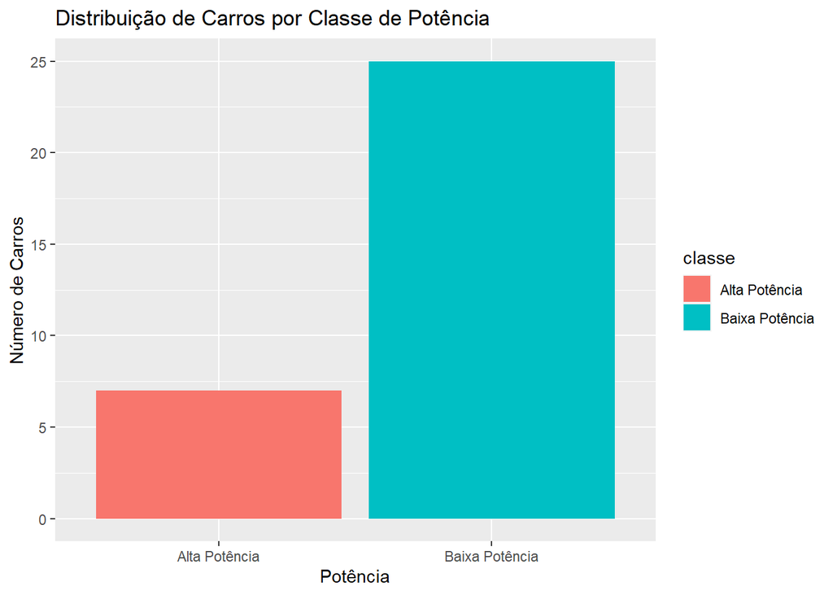

```r
data <- mutate(mtcars, classe = ifelse(hp >= 200, "Alta Potência", "Baixa Potência"))

ggplot(data, aes(x = classe, fill = classe)) +
  geom_bar() +
  labs(x = "Potência", y = "Número de Carros", title = "Distribuição de Carros por Classe de Potência")
```

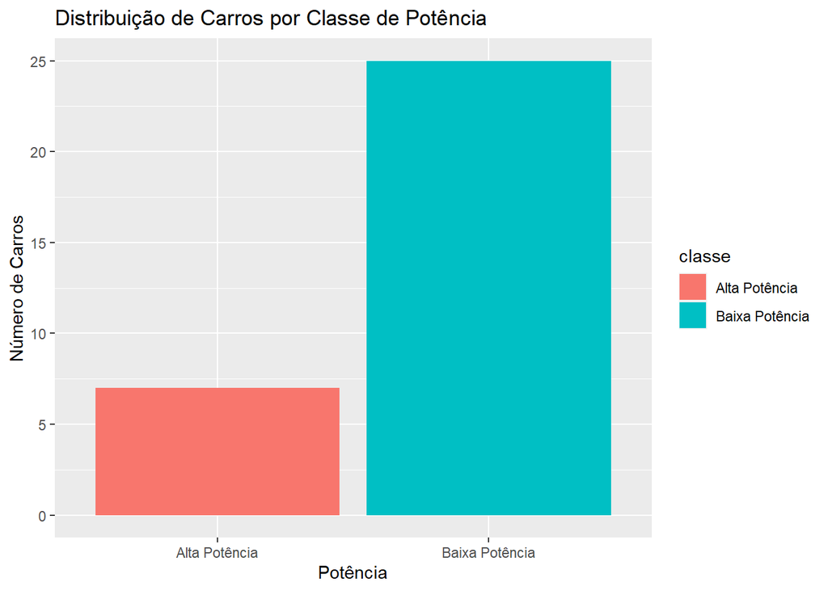

```r
mtcars %>%
  mutate(classe = ifelse(hp >= 200, "Alta Potência", "Baixa Potência")) %>%
  ggplot(aes(x = classe, fill = classe)) +
  geom_bar() +
  labs(x = "Potência", y = "Número de Carros", title = "Distribuição de Carros por Classe de Potência")
```

### 3.3.2 Exemplo 2

```r
mtcars
```

```
##                      mpg cyl  disp  hp drat    wt  qsec vs am gear carb
## Mazda RX4           21.0   6 160.0 110 3.90 2.620 16.46  0  1    4    4
## Mazda RX4 Wag       21.0   6 160.0 110 3.90 2.875 17.02  0  1    4    4
## Datsun 710          22.8   4 108.0  93 3.85 2.320 18.61  1  1    4    1
## Hornet 4 Drive      21.4   6 258.0 110 3.08 3.215 19.44  1  0    3    1
## Hornet Sportabout   18.7   8 360.0 175 3.15 3.440 17.02  0  0    3    2
## Valiant             18.1   6 225.0 105 2.76 3.460 20.22  1  0    3    1
## Duster 360          14.3   8 360.0 245 3.21 3.570 15.84  0  0    3    4
## Merc 240D           24.4   4 146.7  62 3.69 3.190 20.00  1  0    4    2
## Merc 230            22.8   4 140.8  95 3.92 3.150 22.90  1  0    4    2
## Merc 280            19.2   6 167.6 123 3.92 3.440 18.30  1  0    4    4
## Merc 280C           17.8   6 167.6 123 3.92 3.440 18.90  1  0    4    4
## Merc 450SE          16.4   8 275.8 180 3.07 4.070 17.40  0  0    3    3
## Merc 450SL          17.3   8 275.8 180 3.07 3.730 17.60  0  0    3    3
## Merc 450SLC         15.2   8 275.8 180 3.07 3.780 18.00  0  0    3    3
## Cadillac Fleetwood  10.4   8 472.0 205 2.93 5.250 17.98  0  0    3    4
## Lincoln Continental 10.4   8 460.0 215 3.00 5.424 17.82  0  0    3    4
## Chrysler Imperial   14.7   8 440.0 230 3.23 5.345 17.42  0  0    3    4
## Fiat 128            32.4   4  78.7  66 4.08 2.200 19.47  1  1    4    1
## Honda Civic         30.4   4  75.7  52 4.93 1.615 18.52  1  1    4    2
## Toyota Corolla      33.9   4  71.1  65 4.22 1.835 19.90  1  1    4    1
## Toyota Corona       21.5   4 120.1  97 3.70 2.465 20.01  1  0    3    1
## Dodge Challenger    15.5   8 318.0 150 2.76 3.520 16.87  0  0    3    2
## AMC Javelin         15.2   8 304.0 150 3.15 3.435 17.30  0  0    3    2
## Camaro Z28          13.3   8 350.0 245 3.73 3.840 15.41  0  0    3    4
## Pontiac Firebird    19.2   8 400.0 175 3.08 3.845 17.05  0  0    3    2
## Fiat X1-9           27.3   4  79.0  66 4.08 1.935 18.90  1  1    4    1
## Porsche 914-2       26.0   4 120.3  91 4.43 2.140 16.70  0  1    5    2
## Lotus Europa        30.4   4  95.1 113 3.77 1.513 16.90  1  1    5    2
## Ford Pantera L      15.8   8 351.0 264 4.22 3.170 14.50  0  1    5    4
## Ferrari Dino        19.7   6 145.0 175 3.62 2.770 15.50  0  1    5    6
## Maserati Bora       15.0   8 301.0 335 3.54 3.570 14.60  0  1    5    8
## Volvo 142E          21.4   4 121.0 109 4.11 2.780 18.60  1  1    4    2
```

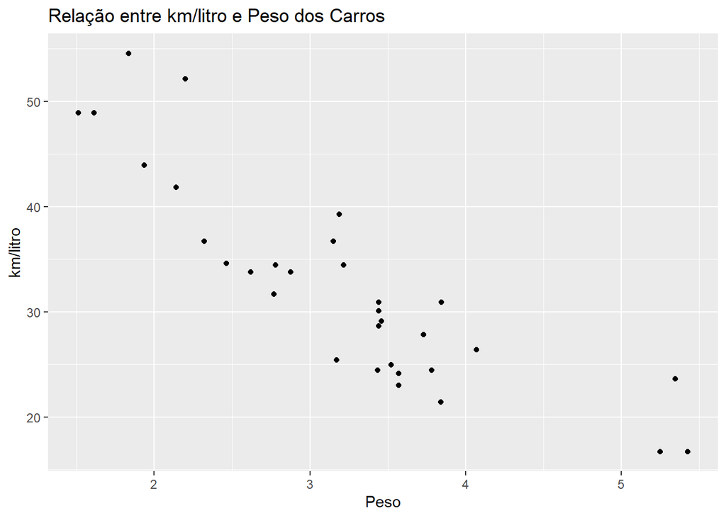

```r
mtcars %>%
  mutate(mpg = mpg * 1.60934) %>%
    ggplot(aes(x = wt, y = mpg)) +
    geom_point() +
    labs(x = "Peso", y = "km/litro", title = "Relação entre km/litro e Peso dos Carros")
```

## 3.4 `filter()`

A função `filter` é uma função do pacote dplyr do R, utilizada para filtrar observações (linhas) de um data frame com base em determinadas condições. Ela permite selecionar apenas as linhas que atendem a certos critérios especificados pelo usuário.

Ao usar a função filter, você especifica uma ou mais condições lógicas para selecionar as linhas desejadas. Essas condições podem ser expressões simples, como igualdades (==), desigualdades (<, >, <=, >=), ou podem ser combinações mais complexas de várias condições usando operadores lógicos, como & (E lógico) e | (OU lógico).

Vamos filtrar carros com cilindros maiores que 6 e potência maior que 200:

```r
carros_filtrados <- filter(mtcars, cyl > 6 & hp > 200)
```

### 3.4.1 Exemplo 3

Quantas amostras existem para cada espécie de flores no conjunto de dados “iris”, considerando apenas as amostras em que o comprimento da sépala (Sepal.Length) seja maior ou igual a 5 e a largura da sépala (Sepal.Width) seja menor ou igual a 3? Apresente essa contagem de amostras por espécie em um gráfico de barras.

```r
data <- iris
```

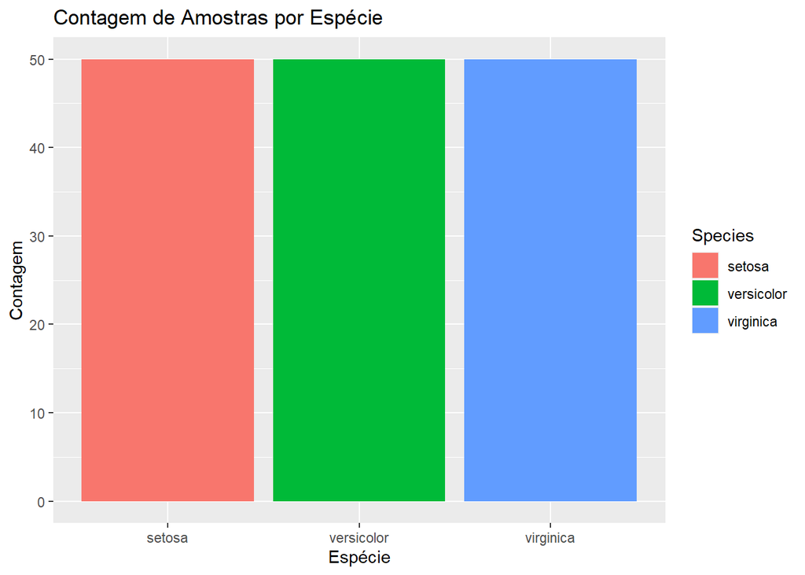

```r
iris %>%
  ggplot(aes(x = Species, fill = Species)) +
  geom_bar() +
  labs(x = "Espécie", y = "Contagem", title = "Contagem de Amostras por Espécie")
```

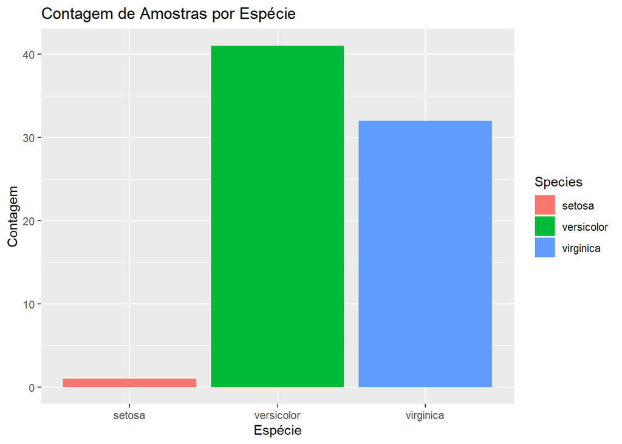

```r
iris %>%
  filter(Sepal.Length >= 5 & Sepal.Width <= 3) %>%
  ggplot(aes(x = Species, fill = Species)) +
  geom_bar() +
  labs(x = "Espécie", y = "Contagem", title = "Contagem de Amostras por Espécie")
```

## 3.5 `summarise()` e `group_by()`

O `group_by` é uma função do pacote `dplyr` do R, que é usado para agrupar dados em um data frame. Essa função é comumente utilizada em conjunto com outras funções do dplyr, como `summarize`, `mutate` e `filter`, para realizar operações em grupos específicos de dados.

Ao usar a função `group_by`, você especifica uma ou mais colunas do data frame pelas quais deseja agrupar os dados. Em seguida, você pode aplicar outras funções do dplyr a esses grupos, obtendo resultados agregados ou modificando os dados dentro de cada grupo separadamente.

A função summarize permite calcular estatísticas resumidas, como média, soma, mínimo, máximo, contagem, entre outros, para diferentes grupos de dados. Você pode agrupar seus dados usando a função group_by antes de aplicar a função summarize. Isso permite que você especifique as variáveis de agrupamento para as quais deseja calcular as estatísticas resumidas.

Neste exemplo, vamos agrupar os carros pelo número de cilindros (cyl) e pelo tipo de transmissão (am). Em seguida, usamos a função summarize para calcular a média da potência (hp), a média do consumo de combustível (mpg) e a contagem do número de carros em cada grupo. O resultado é um novo data frame com as estatísticas resumidas.

```r
mtcars %>%
  group_by(cyl, am)
```

```
## # A tibble: 32 × 11
## # Groups:   cyl, am [6]
##      mpg   cyl  disp    hp  drat    wt  qsec    vs    am  gear  carb
##    <dbl> <dbl> <dbl> <dbl> <dbl> <dbl> <dbl> <dbl> <dbl> <dbl> <dbl>
##  1  21       6  160    110  3.9   2.62  16.5     0     1     4     4
##  2  21       6  160    110  3.9   2.88  17.0     0     1     4     4
##  3  22.8     4  108     93  3.85  2.32  18.6     1     1     4     1
##  4  21.4     6  258    110  3.08  3.22  19.4     1     0     3     1
##  5  18.7     8  360    175  3.15  3.44  17.0     0     0     3     2
##  6  18.1     6  225    105  2.76  3.46  20.2     1     0     3     1
##  7  14.3     8  360    245  3.21  3.57  15.8     0     0     3     4
##  8  24.4     4  147.    62  3.69  3.19  20       1     0     4     2
##  9  22.8     4  141.    95  3.92  3.15  22.9     1     0     4     2
## 10  19.2     6  168.   123  3.92  3.44  18.3     1     0     4     4
## # ℹ 22 more rows
```

```r
mtcars %>%
  group_by(cyl, am) %>%
  summarise(media_hp = mean(hp),
            media_mpg = mean(mpg),
            qtd_carros = n())
```

[output not shown]

```
## # A tibble: 6 × 5
## # Groups:   cyl [3]
##     cyl    am media_hp media_mpg qtd_carros
##   <dbl> <dbl>    <dbl>     <dbl>      <int>
## 1     4     0     84.7      22.9          3
## 2     4     1     81.9      28.1          8
## 3     6     0    115.       19.1          4
## 4     6     1    132.       20.6          3
## 5     8     0    194.       15.0         12
## 6     8     1    300.       15.4          2
```

### 3.5.1 Exemplo 4

Use o pacote dplyr em conjunto com o ggplot2 para realizar uma análise exploratória dos dados e criar uma visualização que **mostre a média de potência (hp) em relação ao número de cilindros (cyl), com as barras agrupadas pelo tipo de transmissão (am)**.

[output not shown]

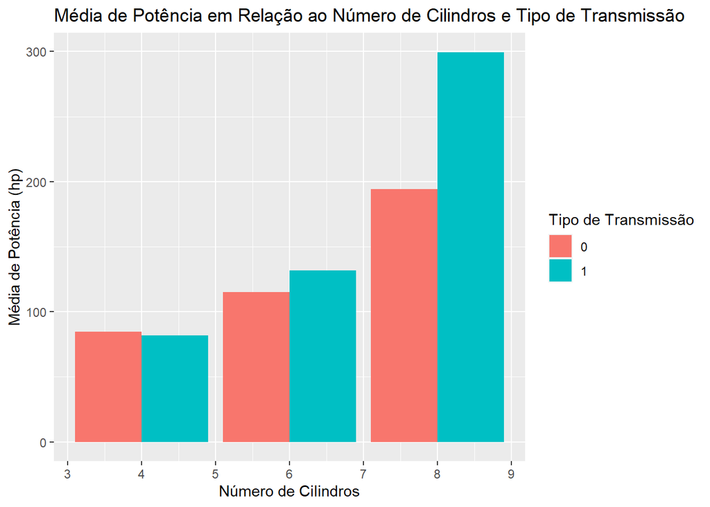

```r
mtcars %>%
  group_by(cyl, am) %>%
    summarise(media_hp = mean(hp))%>%
      ggplot(aes(x = cyl, y = media_hp, fill = factor(am))) +
        geom_bar(stat = "identity", position = "dodge") +
        labs(x = "Número de Cilindros", y = "Média de Potência (hp)", fill = "Tipo de Transmissão", title = "Média de Potência em Relação ao Número de Cilindros e Tipo de Transmissão")
```

### 3.5.2 Exemplo 5

Você possui um conjunto de dados chamado “diamonds” que contém informações sobre características de diamantes, como preço, quilates, corte (cut) e cor (color).

Crie uma visualização em forma de gráfico de barras que mostre a média do preço por quilate (price_per_carat) para cada combinação de corte e cor dos diamantes. Para a visualização, filtre apenas os diamantes que possuem quilates entre 0.5 e 2.

[output not shown]

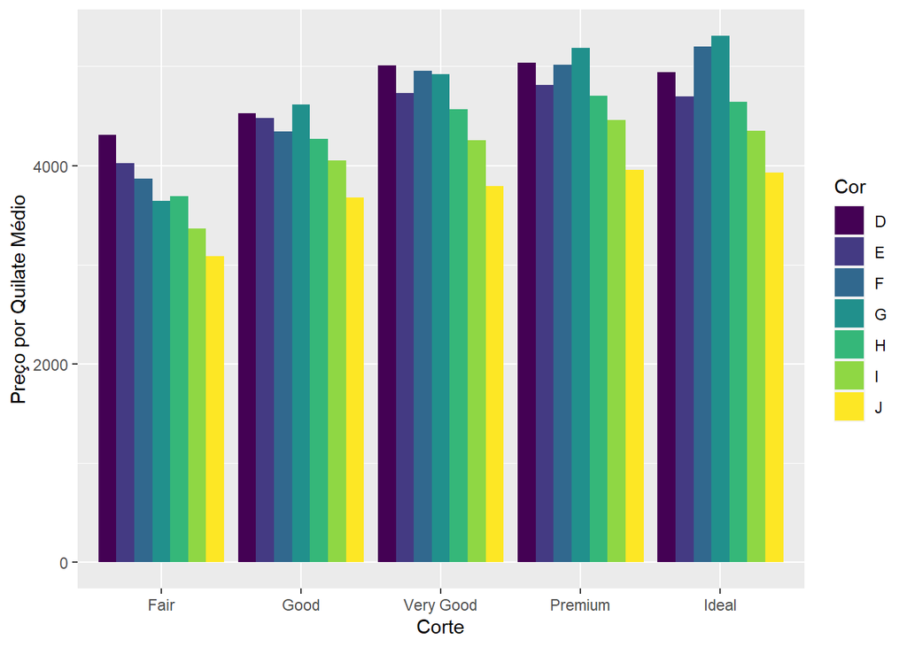

```r
diamonds %>%
  mutate(price_per_carat = price / carat) %>%
  group_by(cut, color) %>%
  filter(carat >= 0.5 & carat <= 2) %>%
  summarise(media_price_per_carat = mean(price_per_carat)) %>%
    ggplot(aes(x = cut, y = media_price_per_carat, fill = color)) +
      geom_bar(stat = "identity", position = "dodge") +
      labs(x = "Corte", y = "Preço por Quilate Médio", fill = "Cor")
```

# 4 Facet

No contexto do R, uma facet é uma função usada para dividir um gráfico em painéis, permitindo visualizar diferentes grupos ou subconjuntos dos dados de forma separada.

A função `facet_wrap()` ou `facet_grid()` são exemplos comuns de funções de facet no pacote ggplot2 do R.

Com o `facet_wrap()`, você pode criar uma grade de painéis que organiza os dados em uma única direção (horizontal ou vertical), enquanto o `facet_grid()` permite criar uma grade bidimensional de painéis com base em duas variáveis.

A função facet é útil quando você deseja comparar visualmente diferentes categorias ou níveis de uma variável em seus dados. Por exemplo, se você tiver dados de vendas por região geográfica, poderá usar o facet para criar um gráfico separado para cada região, permitindo comparar as tendências de vendas em cada área de forma mais clara.

### 4.0.1 Exemplo 6

Vamos plotar um gráfico de dispersão com a variável `mpg` (milhas por galão) no eixo x e a variável `wt` (peso) no eixo y. Usamos o `facet_wrap` para criar um gráfico separado para cada nível da variável `cyl` (número de cilindros do carro).

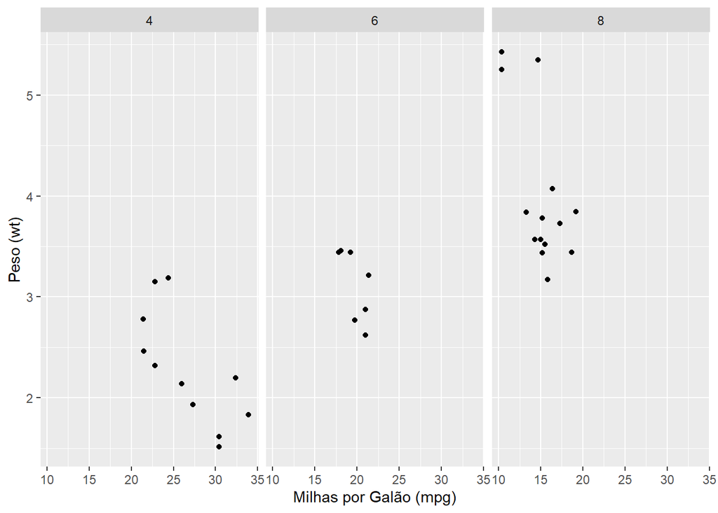

```r
# ggplot(mtcars, aes(x = mpg, y = wt, color = factor(cyl))) +
#  geom_point() +
#  facet_wrap(~ cyl) +
#  labs(x = "Milhas por Galão (mpg)", y = "Peso (wt)")

ggplot(mtcars, aes(x = mpg, y = wt)) +
  geom_point() +
  facet_wrap(~ cyl) +
  labs(x = "Milhas por Galão (mpg)", y = "Peso (wt)")
```

### 4.0.2 Exemplo 7

Estamos criando um gráfico de barras usando a variável `cyl` (número de cilindros) no eixo x. Usamos o `facet_grid` para criar uma grade de painéis com base nas variáveis `am` (tipo de transmissão - automático/manual) e `gear` (número de marchas).

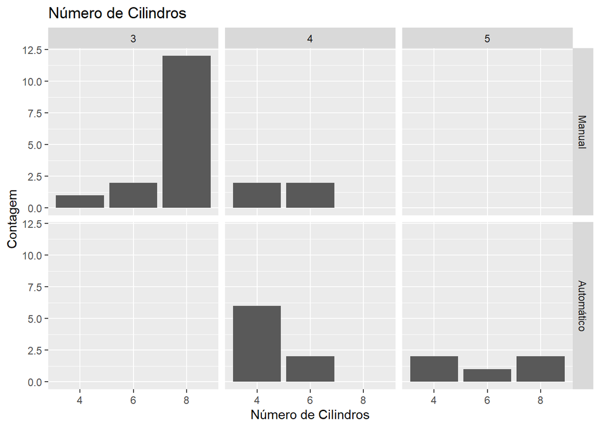

```r
mtcars %>%
  mutate(am = factor(am, labels = c("Manual", "Automático"))) %>%
  ggplot(aes(x = factor(cyl))) +
  geom_bar(position = "dodge") +
  facet_grid(am ~ gear) +
  labs(x = "Número de Cilindros", y = "Contagem") +
  scale_fill_discrete(labels = c("Manual", "Automático")) +
  ggtitle("Número de Cilindros")
```